# ETC5521: Diving Deeply into Data Exploration

Exploring bivariate dependencies

Professor Di Cook

Department of Econometrics and Business Statistics

## The world is full of obvious things which nobody by any chance observes

Quote from Arthur Conan Doyle, The Hound of the Baskervilles

## Outline

- The humble but powerful scatterplot
- Additions and variations
- Transformations to linearity
- (Robust) numerical measures of association
- Simpson’s paradox
- Making null samples to test for association
- Imputing missings
- Multiple associations, exploring network data

## The scatterplot

Scatterplots are the natural plot to make to explore association between two **continuous** (quantitative or numeric) variables.

They are not just for linear relationships but are useful for examining nonlinear patterns, clustering and outliers.

We also can think about scatterplots in terms of statistical distributions: if a histogram shows a marginal distribution, a scatterplot allows us to examine the bivariate distribution of a sample.

## History

- Descartes provided the Cartesian coordinate system in the 17th century, with perpendicular lines indicating two axes.
- It wasn’t until **1832** that the scatterplot appeared, when [John Frederick Herschel](http://www.datavis.ca/milestones/index.php?group=1800%2B) plotted position and time of double stars.
- This is 200 years after the Cartesian coordinate system, and [50 years after bar charts and line charts](http://www.datavis.ca/milestones/index.php?group=1700s) appeared, used in the work of William Playfair to examine economic data.
- Kopf argues that *The scatter plot, by contrast, proved more useful for scientists*, but it clearly is useful for economics today.

http://www.datavis.ca/milestones/

## Language and terminology

Are the words “correlation” and “association” interchangeable?

> In the broadest sense **correlation** is any statistical association, though it commonly refers to the degree to which a pair of variables are **linearly** related. [Wikipedia](https://en.wikipedia.org/wiki/Correlation_and_dependence)

If the relationship is not linear, call it association, and avoid correlated.

## Features of a pair of continuous variables (1/3)

| Feature | Example | Description |
| --- | --- | --- |
| positive trend |  | Low value corresponds to low value, and high to high. |
| negative trend |  | Low value corresponds to high value, and high to low. |
| no trend |  | No relationship |
| strong |  | Very little variation around the trend |
| moderate |  | Variation around the trend is almost as much as the trend |
| weak |  | A lot of variation making it hard to see any trend |

## Features of a pair of continuous variables (2/3)

| Feature | Example | Description |
| --- | --- | --- |
| linear form |  | The shape is linear |
| nonlinear form |  | The shape is more of a curve |
| nonlinear form |  | The shape is more of a curve |
| outliers |  | There are one or more points that do not fit the pattern on the others |
| clusters |  | The observations group into multiple clumps |
| gaps |  | There is a gap, or gaps, but its not clumped |

## Features of a pair of continuous variables (3/3)

| Feature | Example | Description |
| --- | --- | --- |
| barrier |  | There is combination of the variables which appears impossible |
| l-shape |  | When one variable changes the other is approximately constant |
| discreteness |  | Relationship between two variables is different from the overall, and observations are in a striped pattern |
| heteroskedastic |  | Variation is different in different areas, maybe depends on value of x variable |
| weighted |  | If observations have an associated weight, reflect in scatterplot, e.g. bubble chart |

## Additional considerations (Unwin, 2015):

- **causation**: one variable has a direct influence on the other variable, in some way. For example, people who are taller tend to weigh more. The dependent variable is conventionally on the y axis. *It’s not generally possible to tell from the plot that the relationship is causal, which typically needs to be argued from other sources of information.*
- **association**: variables may be related to one another, but through a different variable, eg ice cream sales are positively correlated with beach drownings, is most likely a temperature relationship.
- **conditional relationships**: the relationship between variables is conditionally dependent on another, such as income against age likely has a different relationship depending on retired or not.

## Famous data examples

## Famous scatterplot examples

**Anscombe’s quartet**

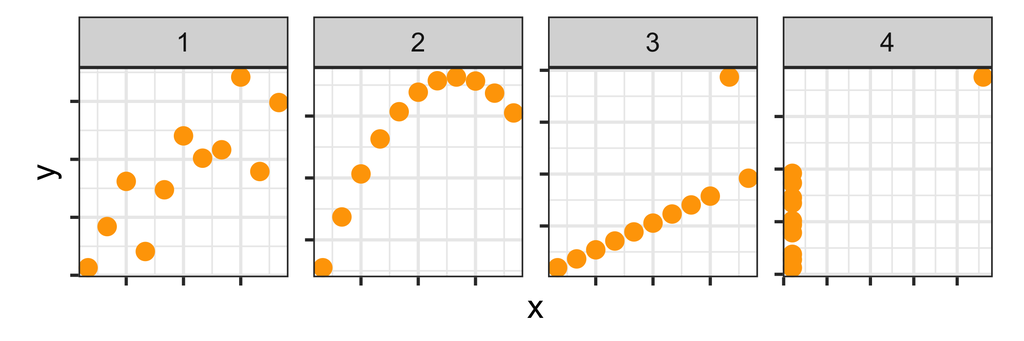

All four sets of Anscombe has same means, standard deviations and correlations, $\bar{x}$ = 9, $\bar{y}$ = 7.5, $s_x$ = 3.3, $s_y$ = 2, $r$ = 0.82.

Numerical statistics are the same, for very different association.

**Datasaurus dozen**

And similarly all 13 sets of the datasaurus dozen have same means, standard deviations and correlations, $\bar{x}$ = 54, $\bar{y}$ = 48, $s_x$ = 17, $s_y$ = 27, $r$ = -0.06.

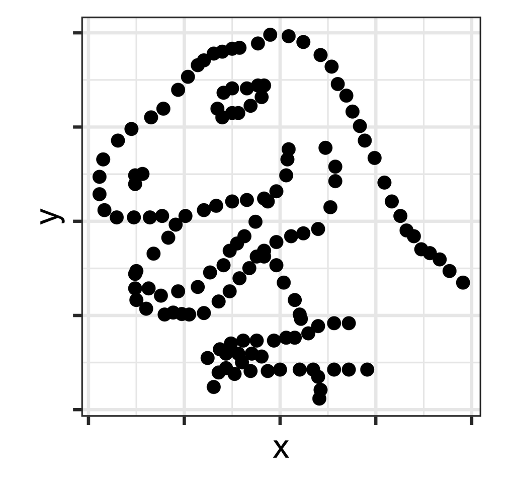

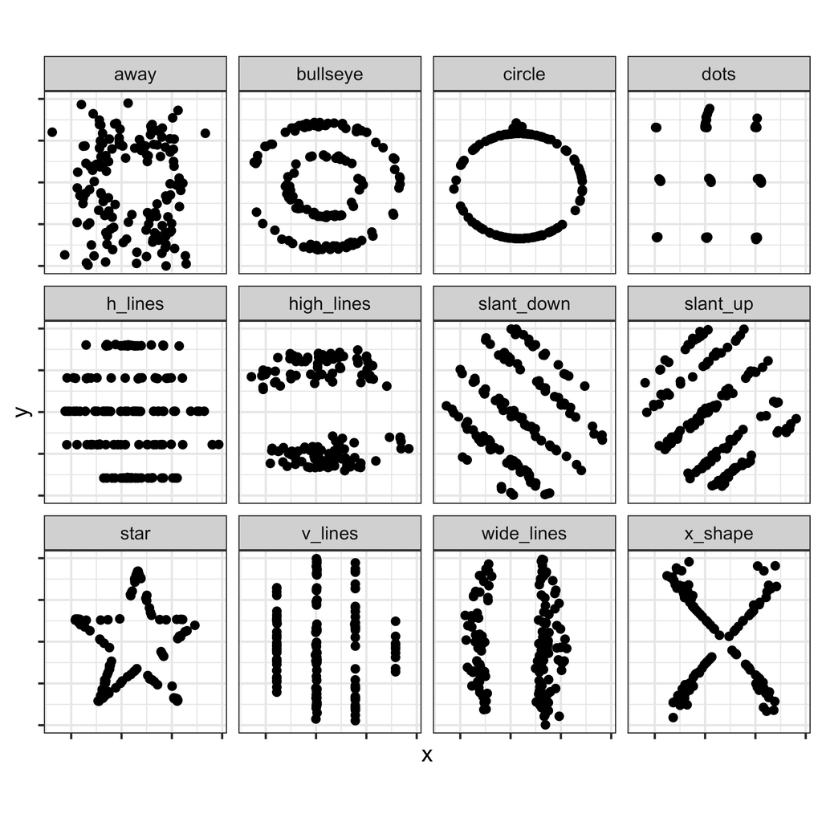

## Aspect ratio

Notice that the scatterplots of the historical examples were made using equal aspect ratio, that is the plot space is a SQUARE not a rectangle.

Most software and most scatterplots you see use unequal aspect ratio. This is an ERROR that is ubiquitous!

When showing two variables, to read association effectively REQUIRES the SQUARE (1:1) aspect ratio.

These slides have more than 50 uses of `aspect.ratio=1`.

Make sure you don’t fall into the trap of failing to control aspect ratio.

## Scatterplot case studies

## Activity: Olympics

**Your turn**

1. Load the individual athlete data for the Summer 2012 Olympic Games (downloaded from the Guardian’s [London 2012 Olympics data](https://www.theguardian.com/sport/series/london-2012-olympics-data))

```r
data(oly12, package = "VGAMdata")
```

2. Make a scatterplot of `Height` vs `Weight`. You’ll see a warning about missing values being removed – what features do you notice? Look for a linear relationship, outliers, discretization, and overplotting (there are more than 10,000 athletes)
3. Are there sport(s) where you would expect a different relationship between height and weight?
4. Count how many athletes compete in each `Sport`. Are the categories well organised, or would you group some of them together?
- Code
- Learn

```r
ggplot(oly12, aes(x = Height, y = Weight, label = Sport)) +
  geom_point()

skimr::skim(oly12)

oly12 |>
  count(Sport, sort = TRUE)

# Consolidate factor levels
oly12 <- oly12 |>
  mutate(Sport = as.character(Sport)) |>
  mutate(Sport = ifelse(grepl("Cycling", Sport),
    "Cycling", Sport
  )) |>
  mutate(Sport = ifelse(grepl("Gymnastics", Sport),
    "Gymnastics", Sport
  )) |>
  mutate(Sport = ifelse(grepl("Athletics", Sport),
    "Athletics", Sport
  )) |>
  mutate(Sport = as.factor(Sport))

# Drill down by sport
ggplot(oly12, aes(x = Height, y = Weight)) +
  geom_point(alpha = 0.5) +
  facet_wrap(~Sport, ncol = 8) +
  theme(aspect.ratio = 1)

# Handle missings, and examine by demographics
oly12 |>
  filter(!(Sport %in% c("Boxing", "Gymnastics", "Synchronised Swimming", "Taekwondo", "Trampoline"))) |>
  mutate(Sport = fct_drop(Sport)) |>
  ggplot(aes(x = Height, y = Weight, colour = Sex)) +
  geom_point(alpha = 0.5) +
  facet_wrap(~Sport, ncol = 7, scales = "free") +
  scale_colour_brewer("", palette = "Dark2") +
  theme(aspect.ratio = 1, axis.text.x = element_text(angle = 90, vjust = 0.5, hjust = 1))
```

Did you notice these interesting patterns?

- Some sports have no data for height, weight
- The positive association between height and weight is visible across sports
- Nonlinear in wrestling?
- An outlier in judo, and football, and archery
- Maybe flatter among swimmers
- Taller in basketball, volleyball and handball
- Shorter in athletics, weightlifting and wrestling
- Little variance in tennis players

Refine plots to make comparisons easier:

- Remove sports with missings
- Overlay model to assess linear relationships
- Drill down into other strata, eg male/female athletes
- Compare in small chunks, one group against the rest

Note: Because the focus is now on males vs females association shape within sport, make plots scale separately.

- Athletics category should have been broken into several more categories like track, field: a shot-putter has a very different physique to a sprinter.
- Generally, clustering of male/female athletes
- Outliers: a tall skinny male archer, a medium height very light female athletics athlete, tall light female weightlifter, tall light male volleyballer
- Canoe slalom athletes, divers, cyclists are tiny.

## Common ways to augment scatterplots (1/2)

| Modification | Example | Purpose |
| --- | --- | --- |
| alpha-blend |  | alleviate overplotting to examine density at centre |
| model overlay |  | focus on the trend |
| model + data |  | trend plus variation |
| density |  | overall distribution, variation and clustering |
| filled density |  | high density locations in distribution (modes), variation and clustering |
| colour |  | relationship with conditioning and lurking variables |

## Common ways to augment scatterplots (2/2)

- 🖼️
- R

**Hexagon binning**

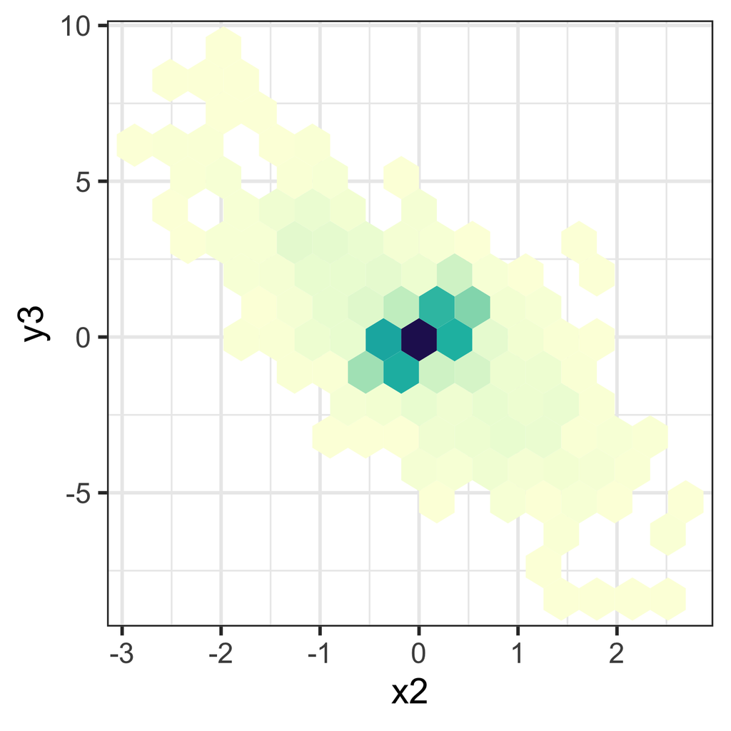

Colour maps to the count of points falling in each hexagonal bin, alleviating overplotting.

**Bubble plot**

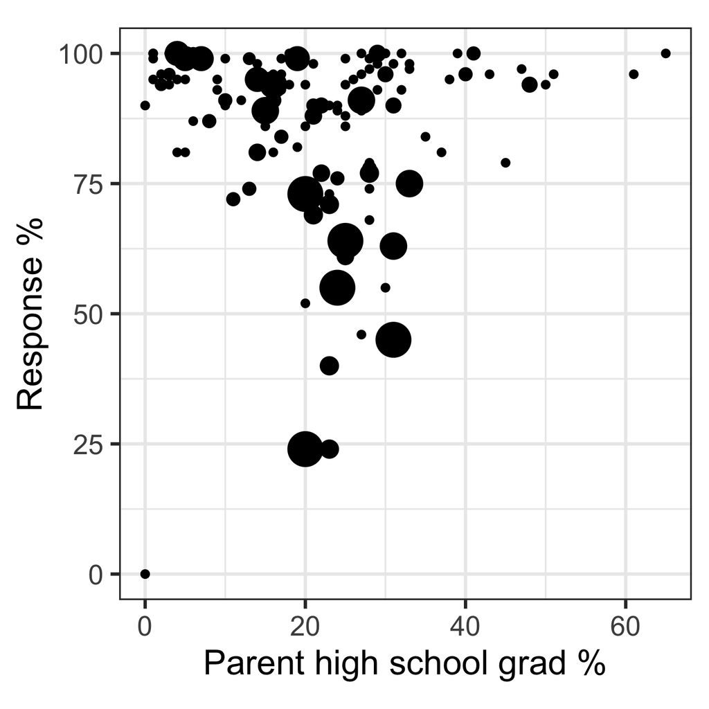

Size of each point maps to an extra (weight) variable.

**High density regions**

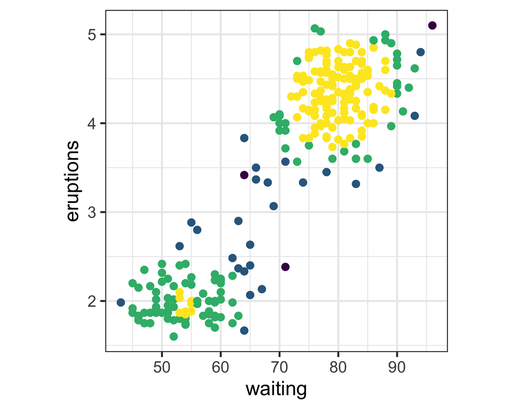

The `gghdr` package colours points by highest density regions (HDRs), revealing modes and labelling outliers beyond the largest region.

```r
ggplot(df, aes(x = x2, y = y3)) +
  geom_hex(bins = 15) +
  scale_fill_continuous_sequential(palette = "YlGnBu") +
  theme(aspect.ratio = 1, legend.position = "none")
```

```r
library(survey)
data(api)
ggplot(apiclus2,
  aes(x=hsg,
      y=pct.resp,
      size=pw)) +
  geom_point() +
  ylab("Response %") +
  xlab("Parent high school grad %") +
  theme(aspect.ratio = 1, legend.position = "none")
```

```r
# install.packages("remotes")
# remotes::install_github("Sayani07/gghdr")
library(gghdr)
ggplot(data = faithful,
    aes(x = waiting,
        y = eruptions)) +
  geom_point(aes(colour = hdr_bin(x = waiting, y = eruptions))) +
  #geom_hdr_rug() +
  scale_colour_viridis_d(direction = -1) +
  theme(aspect.ratio = 1, legend.position = "none")
```

## Activity: Comparing association and spread

**Your turn**

1. Using `oly12`, filter to female athletes in Swimming, Archery, Basketball, Handball, Hockey, Tennis, Weightlifting, and Wrestling. Fit a linear trend of `Weight` on `Height` for each `Sport` and plot them together. How does the *association* between height and weight differ across sports?
2. Now filter to female athletes in Shooting, Modern Pentathlon, and Basketball, and overlay density contours of `Height` and `Weight` by `Sport`. How does the *spread* of the relationship differ across sports?
3. Some of this association may be due to unmeasured (lurking) variables. For example, “Athletics” combines throwing and running events, which have quite different body types. If you were only given `Height` and `Weight`, without `Sport`, could you have detected this hidden structure? What pattern might reveal it?
4. Make a scatterplot and overlaid density contours (try a couple of different bandwidths) of `Height` vs `Weight` for `Sport == "Athletics"` only. Can you detect any multimodality that would hint at the hidden sport subgroup structure?
- Code
- Learn

```r
oly12 |>
  filter(Sport %in% c(
    "Swimming", "Archery", "Basketball",
    "Handball", "Hockey", "Tennis",
    "Weightlifting", "Wrestling"
  )) |>
  filter(Sex == "F") |>
  mutate(Sport = fct_drop(Sport), Sex = fct_drop(Sex)) |>
  ggplot(aes(x = Height, y = Weight, colour = Sport)) +
  geom_smooth(method = "lm", se = FALSE) +
  scale_color_discrete_divergingx(palette = "Zissou 1") +
  theme(
    legend.title = element_blank(),
    legend.position = "bottom",
    legend.direction = "horizontal"
  )

oly12 |>
  filter(Sport %in% c("Shooting", "Modern Pentathlon", "Basketball")) |>
  filter(Sex == "F") |>
  mutate(Sport = fct_drop(Sport), Sex = fct_drop(Sex)) |>
  ggplot(aes(x = Height, y = Weight, colour = Sport)) +
  geom_density2d() +
  scale_color_discrete_divergingx(palette = "Zissou 1") +
  theme(
    legend.title = element_blank(),
    legend.position = "bottom",
    legend.direction = "horizontal"
  )

p1 <- oly12 |>
  filter(Sport == "Athletics") |>
  ggplot(aes(x = Height, y = Weight)) +
  geom_point(alpha = 0.2, size = 4)
p2 <- oly12 |>
  filter(Sport == "Athletics") |>
  ggplot(aes(x = Height, y = Weight)) +
  geom_density2d_filled() +
  theme(legend.position = "none")
p3 <- oly12 |>
  filter(Sport == "Athletics") |>
  ggplot(aes(x = Height, y = Weight)) +
  geom_density2d(binwidth = 0.01)
p4 <- oly12 |>
  filter(Sport == "Athletics") |>
  ggplot(aes(x = Height, y = Weight)) +
  geom_density2d(binwidth = 0.001, color = "white", size = 0.2) +
  geom_density2d_filled(binwidth = 0.001) +
  theme(legend.position = "none")
grid.arrange(p1, p3, p2, p4, ncol = 2)
```

- Weightlifters are much heavier relative to height, swimmers are leaner, and tennis players are mixed (shorter athletes tend to be heavier, taller athletes tend to be lighter): the *association* between height and weight differs by sport.
- Modern pentathlon athletes are uniformly related in height and weight, while shooters are quite varied in body type: the *spread* of the relationship also differs by sport.
- Some of the association is due to unmeasured variables. For example, “Athletics” masks different body types in throwing vs running events — this is a **lurking** variable.
- With only `Height` and `Weight`, the hidden structure is hard to detect directly, but it may appear as multimodality in the joint distribution — as seen (faintly) in the density contours for Athletics. It’s not easy to detect the presence of the additional variable, and thus accurately describe the relationship between height and weight among Olympic athletes.

## Numerical measures of association

## Correlation

- Correlation between variables $x_1$ and $x_2$, with $n$ observations in each.

$$r = \frac{\sum_{i=1}^n (x_{i1}-\bar{x}_1)(x_{i2}-\bar{x}_2)}{\sqrt{\sum_{i=1}^n(x_{i1}-\bar{x}_1)^2\sum_{i=1}^n(x_{i2}-\bar{x}_2)^2}} = \frac{\mbox{covariance}(x_1, x_2)}{(n-1)s_{x_1}s_{x_2}}$$

- Test for statistical significance, whether population correlation could be 0 based on observed $r$, using a $t_{n-2}$ distribution:

$$t=\frac{r}{\sqrt{1-r^2}}\sqrt{n-2}$$

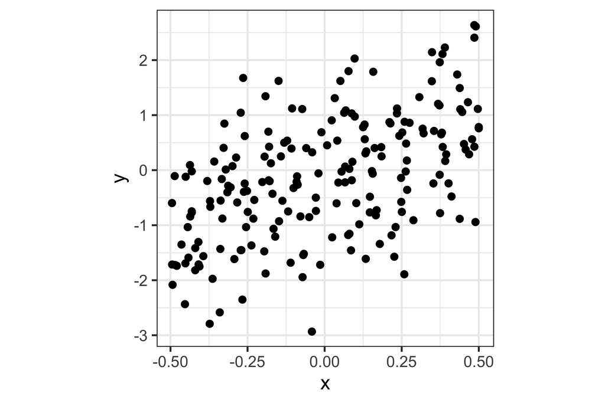

```r
cor(d1$x, d1$y)
```

```
[1] 0.52
```

```r
cor.test(d1$x, d1$y)
```

```
    Pearson's product-moment correlation

data:  d1$x and d1$y
t = 9, df = 198, p-value = 2e-15
alternative hypothesis: true correlation is not equal to 0
95 percent confidence interval:
 0.41 0.62
sample estimates:
 cor
0.52
```

## Problems with correlation (1/2)

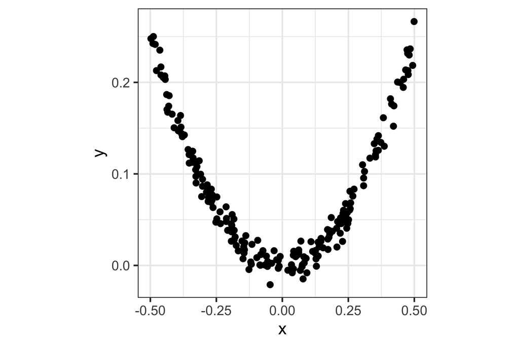

```r
cor(d2$x, d2$y)
```

```
[1] -0.05
```

```r
cor.test(d2$x, d2$y)
```

```
    Pearson's product-moment correlation

data:  d2$x and d2$y
t = -0.7, df = 198, p-value = 0.5
alternative hypothesis: true correlation is not equal to 0
95 percent confidence interval:
 -0.187  0.089
sample estimates:
  cor
-0.05
```

It does not summarise non-linear associations.

## Problems with correlation (2/2)

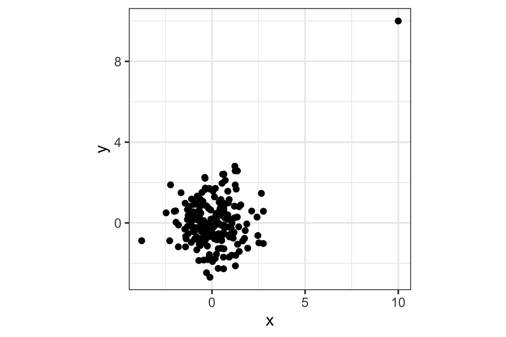

All observations

```
$estimate
cor
0.3

$statistic
  t
4.4

$p.value
[1] 1.6e-05
```

Without outlier

```
$estimate
   cor
-0.012

$statistic
    t
-0.17

$p.value
[1] 0.87
```

It is affected by extreme values.

## Perceiving correlation

- 🖼️
- answers
- R

Let’s play a game: Guess the correlation!

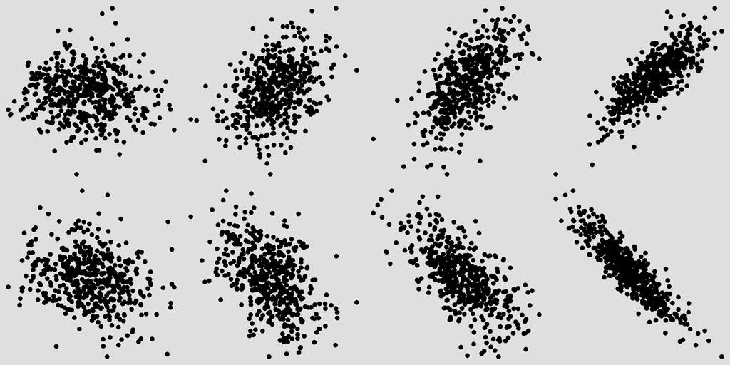

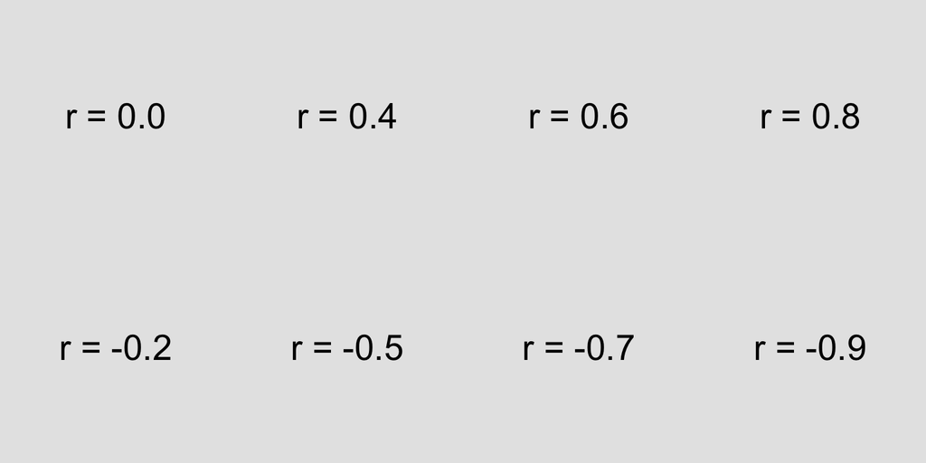

Generally, people don’t do very well at this task. Typically people under-estimate $r$ from scatterplots, particularly when it is around 0.4-0.7. The variation in a scatterplot perceptually doesn’t vary is not linearly with $r$.

When someone says *correlation is 0.5* it sounds impressive. BUT when someone shows you a scatterplot of data that has correlation 0.5, you will say that’s a weak relationship.

```r
set.seed(7777)
vc <- matrix(c(1, 0, 0, 1), ncol = 2, byrow = T)
d <- as_tibble(rmvnorm(500, sigma = vc))
p1 <- ggplot(d, aes(x = V1, y = V2)) +
  geom_point() +
  theme_void() +
  theme(
    aspect.ratio = 1,
    plot.background = element_rect(fill = "gray90")
  )
vc <- matrix(c(1, 0.4, 0.4, 1), ncol = 2, byrow = T)
d <- as_tibble(rmvnorm(500, sigma = vc))
p2 <- ggplot(d, aes(x = V1, y = V2)) +
  geom_point() +
  theme_void() +
  theme(
    aspect.ratio = 1,
    plot.background = element_rect(fill = "gray90")
  )
vc <- matrix(c(1, 0.6, 0.6, 1), ncol = 2, byrow = T)
d <- as_tibble(rmvnorm(500, sigma = vc))
p3 <- ggplot(d, aes(x = V1, y = V2)) +
  geom_point() +
  theme_void() +
  theme(
    aspect.ratio = 1,
    plot.background = element_rect(fill = "gray90")
  )
vc <- matrix(c(1, 0.8, 0.8, 1), ncol = 2, byrow = T)
d <- as_tibble(rmvnorm(500, sigma = vc))
p4 <- ggplot(d, aes(x = V1, y = V2)) +
  geom_point() +
  theme_void() +
  theme(
    aspect.ratio = 1,
    plot.background = element_rect(fill = "gray90")
  )
vc <- matrix(c(1, -0.2, -0.2, 1), ncol = 2, byrow = T)
d <- as_tibble(rmvnorm(500, sigma = vc))
p5 <- ggplot(d, aes(x = V1, y = V2)) +
  geom_point() +
  theme_void() +
  theme(
    aspect.ratio = 1,
    plot.background = element_rect(fill = "gray90")
  )
vc <- matrix(c(1, -0.5, -0.5, 1), ncol = 2, byrow = T)
d <- as_tibble(rmvnorm(500, sigma = vc))
p6 <- ggplot(d, aes(x = V1, y = V2)) +
  geom_point() +
  theme_void() +
  theme(
    aspect.ratio = 1,
    plot.background = element_rect(fill = "gray90")
  )
vc <- matrix(c(1, -0.7, -0.7, 1), ncol = 2, byrow = T)
d <- as_tibble(rmvnorm(500, sigma = vc))
p7 <- ggplot(d, aes(x = V1, y = V2)) +
  geom_point() +
  theme_void() +
  theme(
    aspect.ratio = 1,
    plot.background = element_rect(fill = "gray90")
  )
vc <- matrix(c(1, -0.9, -0.9, 1), ncol = 2, byrow = T)
d <- as_tibble(rmvnorm(500, sigma = vc))
p8 <- ggplot(d, aes(x = V1, y = V2)) +
  geom_point() +
  theme_void() +
  theme(
    aspect.ratio = 1,
    plot.background = element_rect(fill = "gray90")
  )
grid.arrange(p1, p2, p3, p4, p5, p6, p7, p8, ncol = 4)
```

## Robust correlation measures (1/2)

- Spearman (based on ranks)
  - Sort each variable, and return rank (of actual value)
  - Compute correlation between ranks of each variable

```r
set.seed(60)
df <- tibble(
  x = c(round(rnorm(5), 1), 3, 10),
  y = c(round(rnorm(5), 1), -3, 10)
) |>
  mutate(xr = rank(x), yr = rank(y))
df
```

```
# A tibble: 7 × 4
      x     y    xr    yr
  <dbl> <dbl> <dbl> <dbl>
1   0.7  -1.7     5     2
2   0.5   1.1     4     6
3  -0.6   0.3     2     4
4  -0.2  -0.9     3     3
5  -1.7   0.4     1     5
6   3    -3       6     1
7  10    10       7     7
```

```r
cor(df$x, df$y)
```

```
[1] 0.79
```

```r
cor(df$xr, df$yr)
```

```
[1] -0.036
```

```r
cor(df$x, df$y, method = "spearman")
```

```
[1] -0.036
```

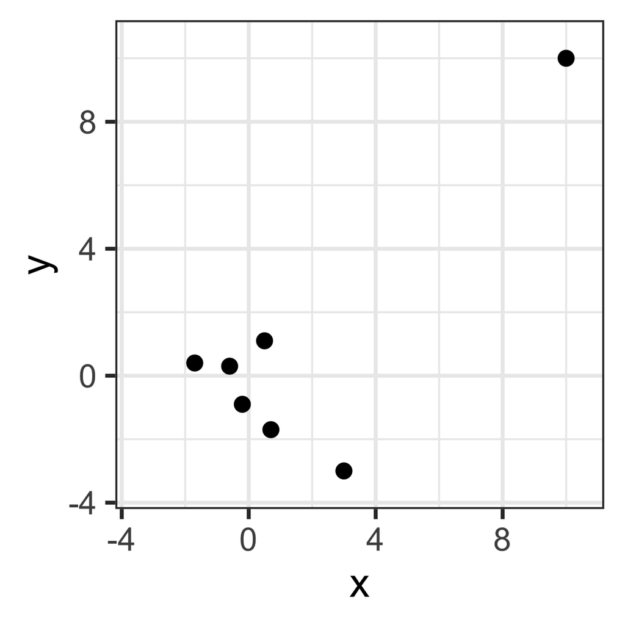

```r
ggplot(df, aes(x, y)) +
  geom_point() +
  xlim(c(-3.5, 10.5)) + ylim(c(-3.5, 10.5)) +
  theme(aspect.ratio=1)
```

## Robust correlation measures (2/2)

- Kendall $\tau$ (based on comparing pairs of observations)
  - Sort each variable, and return rank (of actual value)
  - For all pairs of observations $(x_i, y_i), (x_j, y_j)$ compare ranks to determine if **concordant**, relatively $x_i < x_j, y_i < y_j$ or $x_i > x_j, y_i > y_j$, or **discordant**, $x_i < x_j, y_i > y_j$ or $x_i > x_j, y_i < y_j$.

$$\tau = \frac{n_c-n_d}{\frac12 n(n-1)}$$

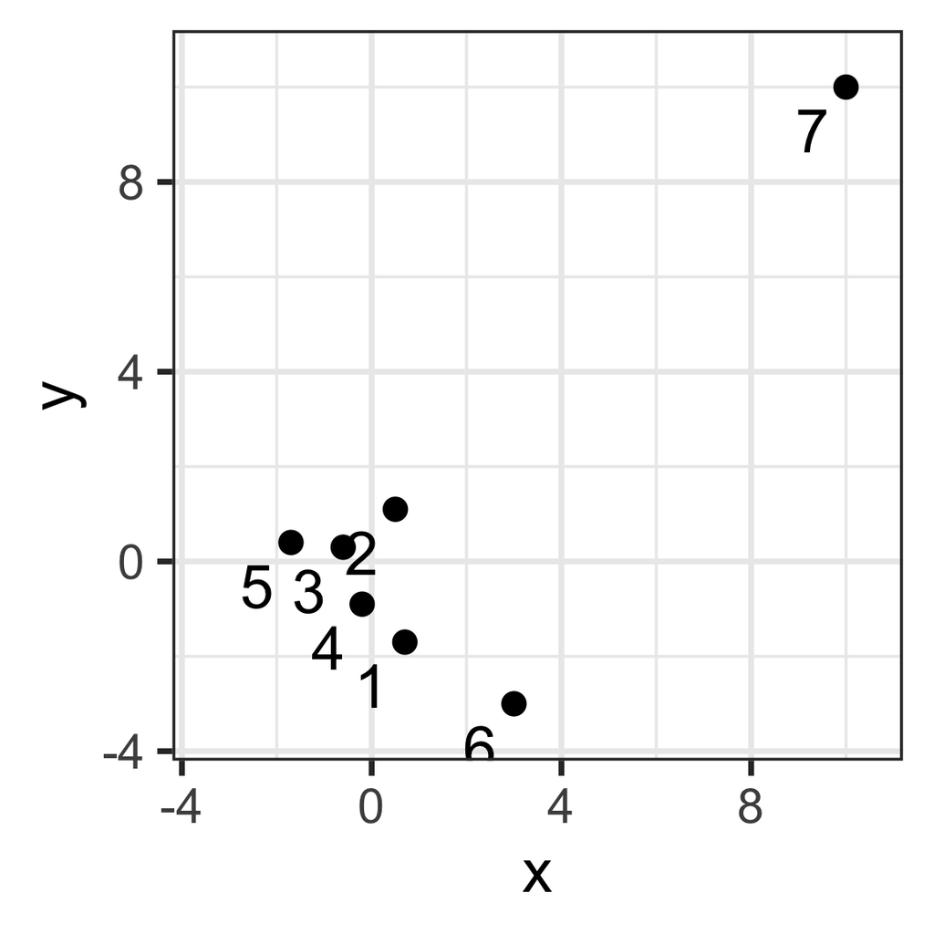

```
# A tibble: 7 × 4
      x     y    xr    yr
  <dbl> <dbl> <dbl> <dbl>
1   0.7  -1.7     5     2
2   0.5   1.1     4     6
3  -0.6   0.3     2     4
4  -0.2  -0.9     3     3
5  -1.7   0.4     1     5
6   3    -3       6     1
7  10    10       7     7
```

```r
cor(df$x, df$y)
```

```
[1] 0.79
```

```r
cor(df$x, df$y, method = "kendall")
```

```
[1] -0.14
```

## Comparison of correlation measures

| sample | corr | spearman | kendall |
| --- | --- | --- | --- |
|  | 0.52 | 0.512 | 0.355 |
|  | -0.05 | -0.087 | -0.073 |
|  | 0.30 | -0.023 | -0.014 |

Robust calculation corrects outlier problems, but nothing measures the non-linear association.

## Transformations

for skewness, heteroskedasticity and linearising relationships, and to emphasize association

## Circle of transformations for linearising

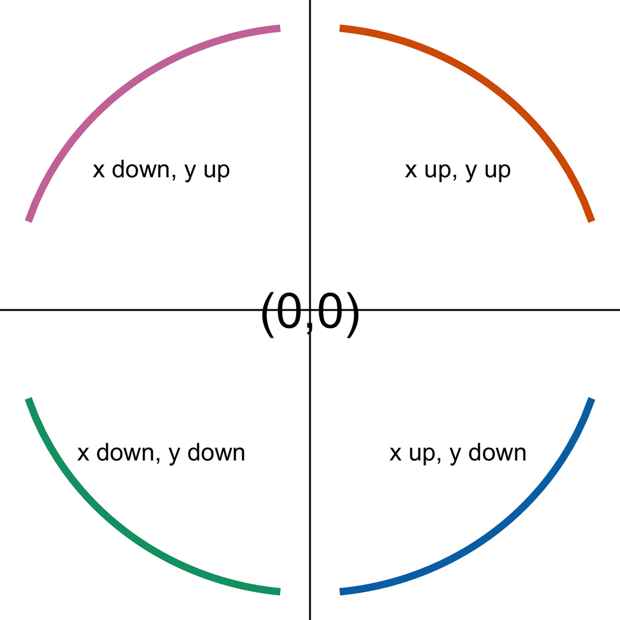

Remember the power ladder:

-1, 0, 1/3, 1/2, 1, 2, 3, 4

1. Look at the shape of the relationship.
2. Imagine this to be a number plane, and depending on which quadrant the shape falls in, you either transform $x$ or $y$, up or down the ladder: `+,+` both up; `+,-` x up, y down; `-,-` both down; `-,+` x down, y up

If there is heteroskedasticity, try transforming $y$, may or may not help

## Activity: Fisherman’s Reach crabs

**Your turn**

1. Load the [Fisherman’s Reach crabs data](https://ddde.numbat.space/data/fr-crab.csv), collected by measuring 62 mud crabs.
2. Make a scatterplot of `Wgt` by `Length.NSW`. Describe the relationship. (Which variable should be the dependent variable, on the $y$ axis?)
3. Fit a linear model of `Wgt` on `Length.NSW` and plot the residuals. Is there evidence of nonlinearity or heteroskedasticity?
4. Using the circle of transformations, try transforming `Wgt` (e.g. cube root, square root, log10) to linearise the relationship. Which works best, and why?
5. Is there possibly a lurking variable, that can explain the nonlinearity?

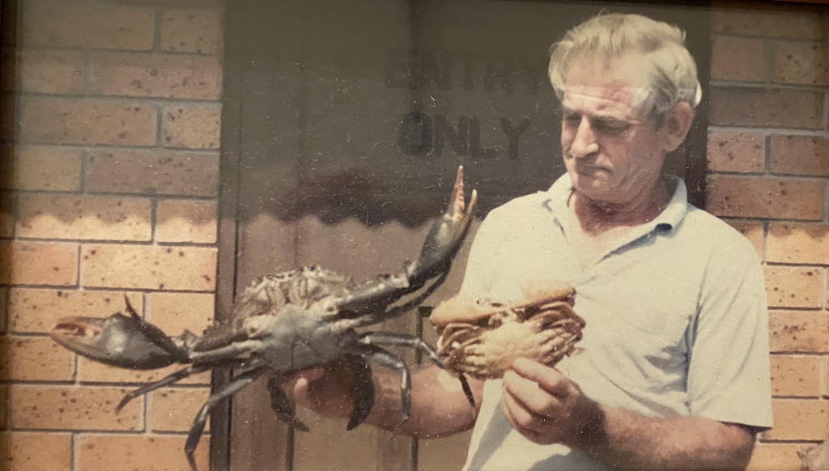

- Code
- Learn

```r
library(broom)

fr_crabs <- read_csv("https://ddde.numbat.space/data/fr-crab.csv") |>
  mutate(Sex = factor(Sex, levels = c(1, 2), labels = c("m", "f")))

ggplot(fr_crabs, aes(x = Length.NSW, y = Wgt)) +
  geom_point()

# Fit a linear model, and check the residuals
cr_lm <- lm(Wgt ~ Length.NSW, data = fr_crabs)
fr_crabs <- augment(cr_lm, fr_crabs)
ggplot(fr_crabs, aes(x = Length.NSW, y = Wgt)) +
  geom_point() +
  geom_smooth(method = "lm", se = FALSE)
ggplot(fr_crabs, aes(x = Length.NSW, y = .resid)) +
  geom_point()

# Try transformations of Wgt to linearise the relationship
ggplot(fr_crabs, aes(x = Length.NSW, y = Wgt^(1 / 3))) +
  geom_point() +
  ylab("Cube root Wgt")
ggplot(fr_crabs, aes(x = Length.NSW, y = Wgt)) +
  geom_point() +
  scale_y_sqrt() +
  ylab("Square root Wgt")
ggplot(fr_crabs, aes(x = Length.NSW, y = Wgt)) +
  geom_point() +
  scale_y_log10() +
  ylab("Log10 Wgt")

# Check for a lurking variable
ggplot(fr_crabs, aes(x = Length.NSW, y = Wgt, colour = Sex)) +
  geom_point() +
  scale_colour_brewer(palette = "Dark2") +
  theme(legend.position = "bottom")

# Fit the cube root model to males only
fr_crabs_m <- fr_crabs |>
  filter(Sex == "m")
cr_m_lm <- lm(Wgt^(1 / 3) ~ Length.NSW, data = fr_crabs_m)
fr_crabs_m <- augment(cr_m_lm, fr_crabs_m)
coefs <- tidy(cr_m_lm)
ggplot(fr_crabs_m, aes(x = Length.NSW, y = Wgt^(1 / 3))) +
  geom_point() +
  geom_abline(intercept = coefs$estimate[1], slope = coefs$estimate[2])
```

- Weight is the dependent variable: it should be on the $y$ axis, because weight is related to the volume of the crab, which scales with length$^p$, not the reverse.
- The raw scatterplot is positive, strong, and a little nonlinear. Fitting a linear model and examining the residuals reveals a U-shape and clear heteroskedasticity, confirming the nonlinearity.
- Cube root, square root, and log10 transformations of `Wgt` all reduce the curvature to varying degrees, consistent with a physical model where weight scales roughly with length-cubed.
- Colouring by `Sex` reveals a **lurking variable**: males and females follow somewhat different Length-Weight relationships, and restricting to males and using a cube root transformation gives the best-fitting, most linear relationship — matching the physical intuition that weight is proportional to length$^3$.

## Interference between skewness and association

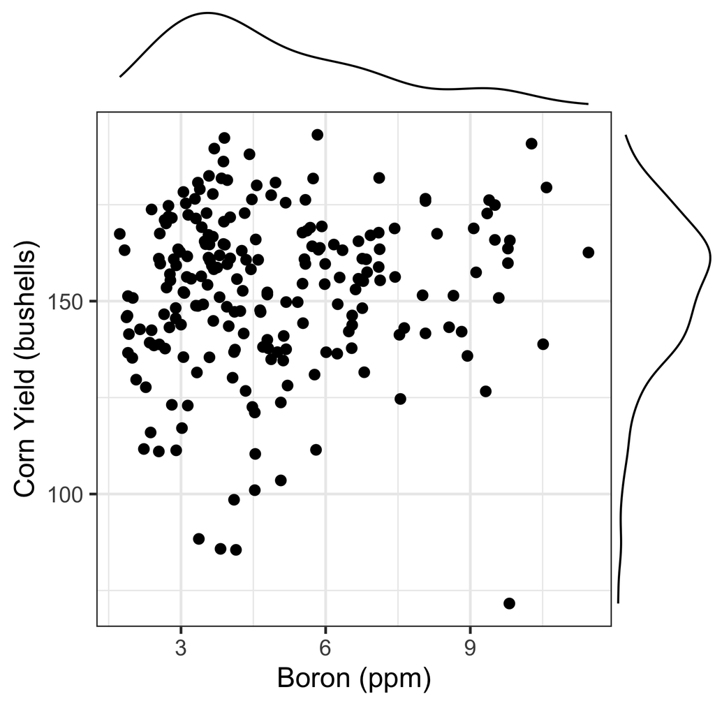

```r
baker <- read_csv(here("data/baker.csv"))
p <- ggplot(baker, aes(x = B, y = Corn97BU)) +
  geom_point() +
  xlab("Boron (ppm)") +
  ylab("Corn Yield (bushells)")
ggMarginal(p, type = "density")
```

- Explanation
- Transform

Interplay between skewness and association

Data is from a soil chemical analysis of a farm field in Iowa. Is there a relationship between Yield and Boron?

You can get a marginal plot of each variable added to the scatterplot using `ggMarginal`. This is useful for assessing the skewness in each variable.

Boron is right-skewed Yield is left-skewed. With skewed distributions in marginal variables it is hard to assess the relationship between the two. Make a transformation to fix, first.

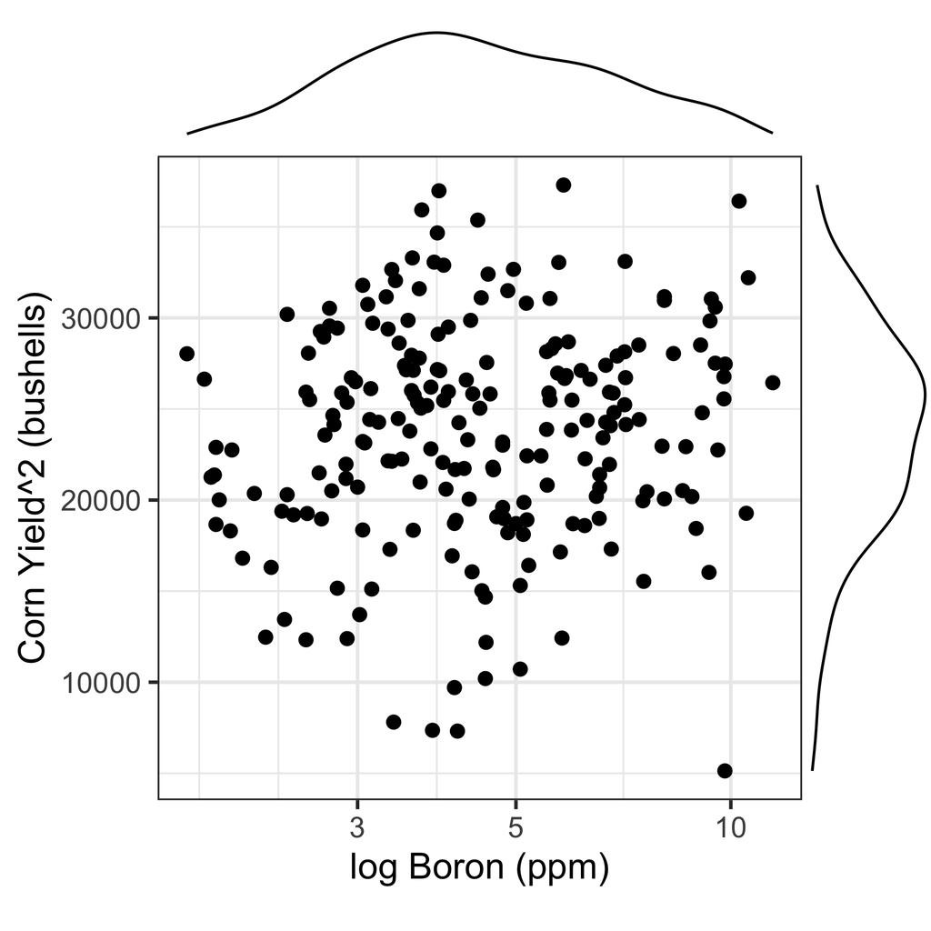

```r
p <- ggplot(
  baker,
  aes(x = B, y = Corn97BU^2)
) +
  geom_point() +
  xlab("log Boron (ppm)") +
  ylab("Corn Yield^2 (bushells)") +
  scale_x_log10()
ggMarginal(p, type = "density")
```

## Checking it with visual inference lineup

- Soils
- R
- Olympics
- R

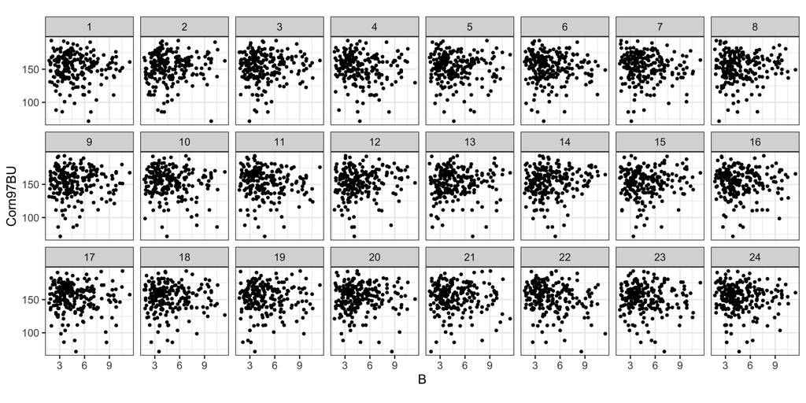

```r
set.seed(932)
ggplot(
  lineup(null_permute("Corn97BU"), baker, n = 24),
  aes(x = B, y = Corn97BU)
) +
  geom_point(size=1) +
  facet_wrap(~.sample, ncol = 8)
```

All but one of the panels have had the association broken by permuting one variable. There is no association in these data sets, and hence plots. Does the data plot stand out as being different from the null (no association) plots?

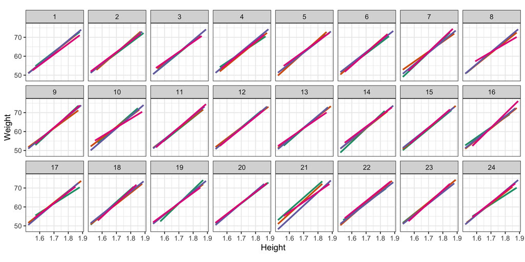

```r
set.seed(933)
data(oly12, package = "VGAMdata")
oly12_sub <- oly12 |>
  filter(Sport %in% c(
    "Swimming", "Archery",
    "Hockey", "Tennis"
  )) |>
  filter(Sex == "F") |>
  mutate(Sport = fct_drop(Sport), Sex = fct_drop(Sex))

ggplot(
  lineup(null_permute("Sport"), oly12_sub, n = 24),
  aes(x = Height, y = Weight, colour = Sport)
) +
  geom_smooth(method = "lm", se = FALSE) +
  scale_colour_brewer("", palette = "Dark2") +
  facet_wrap(~.sample, ncol = 8) +
  theme(legend.position = "none")
```

All but one of the panels have had the association broken by permuting the Sport label. There is no difference in the association between weight and height across sports in these data sets, and hence plots. Does the data plot stand out as being different from the null (no association difference between sports) plots?

## Activity: Case study: Soils

**Your turn**

1. Using the `baker` soils data, make a scatterplot (with marginal densities, and a 2D density overlay) of Corn Yield$^2$ (`Corn97BU^2`) against Iron (`Fe`). Is there a relationship? Could there be a lurking variable?
2. Colour the points by whether Calcium (`Ca`) is high (> 5200 ppm) or low. How does this change your interpretation of the relationship between Iron and Yield?
- Code
- Learn

```r
p <- ggplot(
  baker,
  aes(x = Fe, y = Corn97BU^2)
) +
  geom_density2d(colour = "orange") +
  geom_point() +
  xlab("Iron (ppm)") +
  ylab("Corn Yield^2 (bushells)")
ggMarginal(p, type = "density")

ggplot(baker, aes(
  x = Fe, y = Corn97BU^2,
  colour = ifelse(Ca > 5200,
    "high", "low"
  )
)) +
  geom_point() +
  xlab("Iron (ppm)") +
  ylab("Corn Yield^2 (bushells)") +
  scale_colour_brewer("", palette = "Dark2") +
  theme(
    aspect.ratio = 1,
    legend.position = "bottom",
    legend.direction = "horizontal"
  )
```

[output not shown]

- The raw scatterplot of Yield$^2$ against Iron appears to have two different patterns — this hints at a **lurking variable**.
- Colouring by high vs low Calcium (> 5200 ppm) reveals the structure: if calcium levels in the soil are high, yield is consistently high regardless of iron. If calcium levels are low, there is a positive relationship between yield and iron, with higher iron leading to higher yields.

## Scales, benchmarks, calibration matter

- 🖼️
- about
- R
- Learn

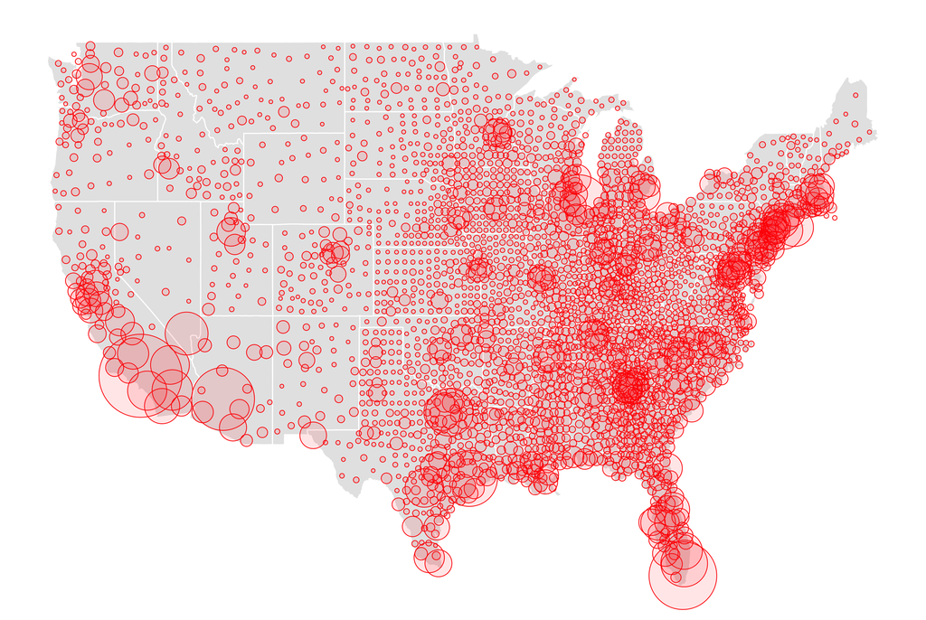

This bubble plot here shows total count of COVID-19 incidence (as of Aug 30, 2020) for every county in the USA, inspired by the [New York Times coverage](https://www.nytimes.com/news-event/coronavirus).

```r
load(here("data/nyt_covid.rda"))
usa <- map_data("state")
ggplot() +
  geom_polygon(
    data = usa,
    aes(x = long, y = lat, group = group),
    fill = "grey90", colour = "white"
  ) +
  geom_point(
    data = nyt_county_total,
    aes(x = lon, y = lat, size = cases),
    colour = "red", shape = 1
  ) +
  geom_point(
    data = nyt_county_total,
    aes(x = lon, y = lat, size = cases),
    colour = "red", fill = "red", alpha = 0.1, shape = 16
  ) +
  scale_size("", range = c(1, 30)) +
  theme_map() +
  theme(legend.position = "none")
```

Where has COVID-19 hit the hardest?

Where are there more people?

This plot tells you NOTHING except where the population centres are in the USA.

To understand relative incidence/risk, report COVID numbers relative the population. For example, number of cases per 100,000 people.

## Beyond quantitative variables

## When variables are not quantitative

What do you do if the variables are not continuous/quantitative?

Type of variable determines the appropriate mapping.

- Continuous and categorical: side-by-side boxplots, side-by-side density plots
- Both categorical: faceted bar charts, stacked bar charts, mosaic plots, double decker plots

## Mosaic plots (1/2)

Read off the proportions of one variable relative to the other.

Number of `book`s at home by mother’s education (1 = less than ISCED 1, …, 4 = ISCED 3A), for 2022 PISA students in Turkey (learningtower package).

- ISCED 1: Elementary/primary school completed
- ISCED 2: Middle school / junior high completed
- ISCED 3A: Academic high school diploma

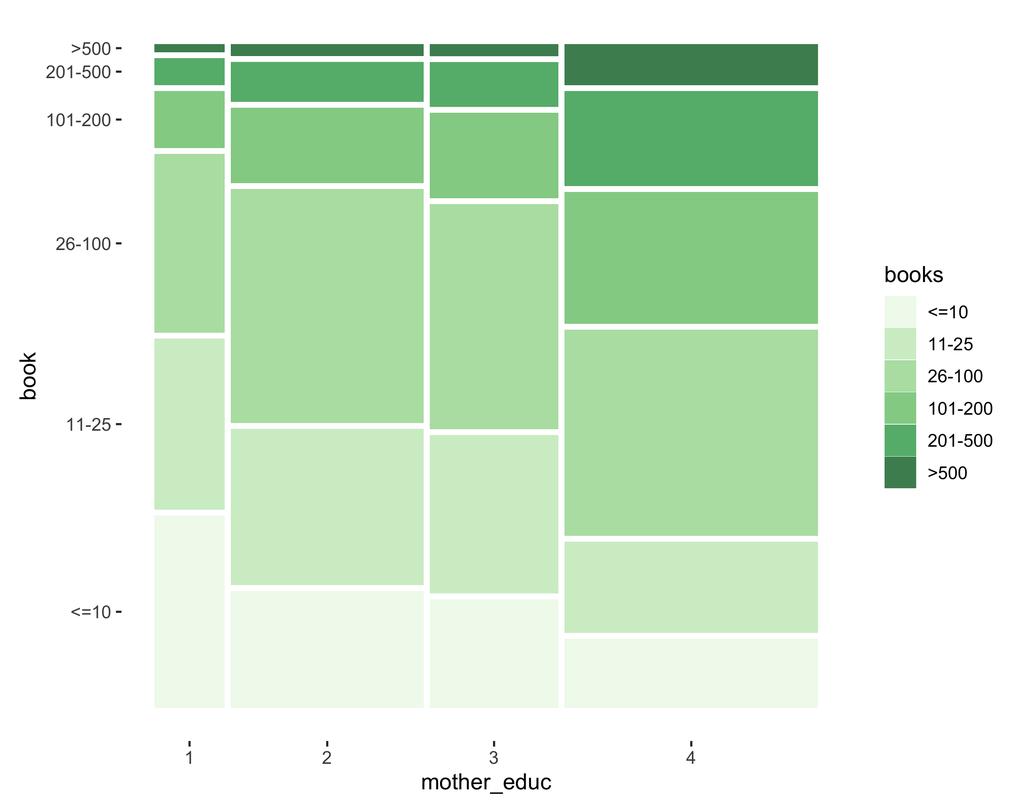

```r
library(vcd)
library(ggmosaic)
load(here::here("data/student_turkey.rda"))

tur_book <- student_tur |>
  filter(!is.na(book),
         !is.na(mother_educ),
         !is.na(gender),
         !is.na(computer),
         !is.na(room)) |>
  mutate(book = as.character(book)) |>
  mutate(book = ifelse(book %in% c("0", "1-10"), "<=10", book)) |>
  mutate(
    book = factor(book, levels = c("<=10", "11-25",
      "26-100", "101-200", "201-500", "More than 500"),
      labels = c("<=10", "11-25",
      "26-100", "101-200", "201-500", ">500")),
    mother_educ = factor(mother_educ,
      levels = c("less than ISCED1", "ISCED 1", "ISCED 2", "ISCED 3A"),
      labels = c("1", "2", "3", "4")
    )
  )

ggplot(tur_book) +
  geom_mosaic(aes(x = product(book, mother_educ),
    fill = book)) +
   scale_fill_discrete("books", palette = "Greens") +
  theme_mosaic()
```

## Mosaic plots (2/2)

The third variable would be interleaved on the horizontal axis.

A fourth variable would be interleaved on the vertical axis.

But it gets increasingly difficult to digest the different proportions.

- 3
- 4

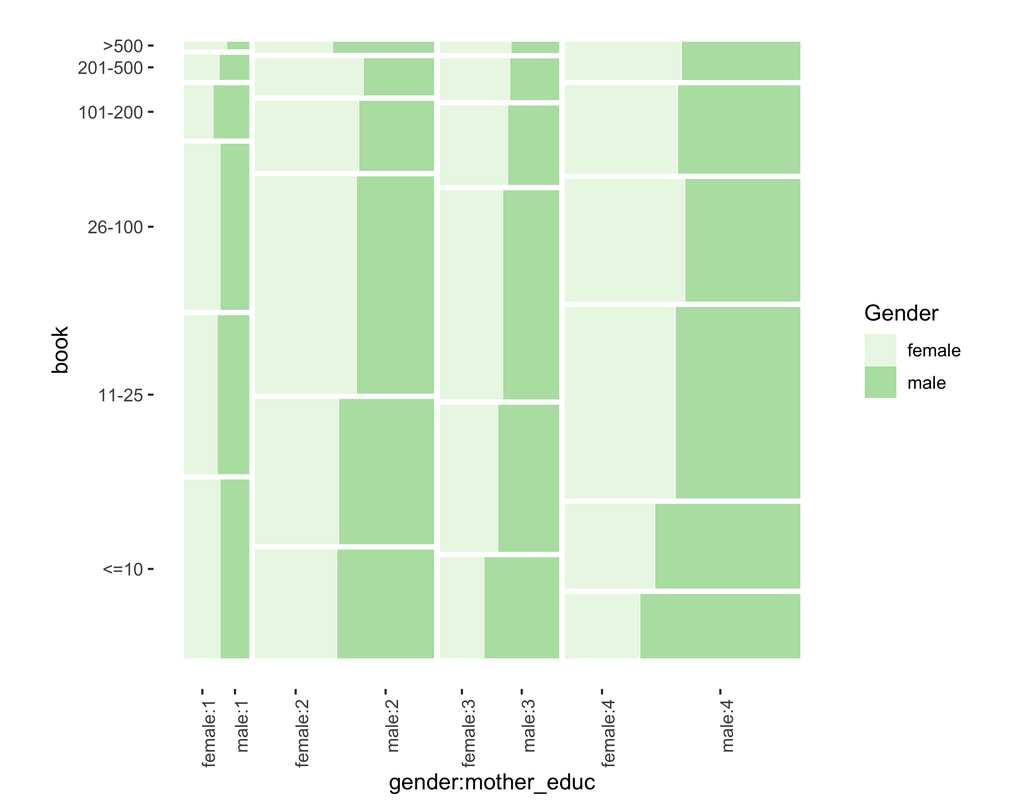

```r
ggplot(tur_book) +
  geom_mosaic(aes(x = product(gender, book,
         mother_educ),
    fill = gender),
    ) +
   scale_fill_discrete("Gender", palette = "Greens") +
  theme_mosaic() +
  theme(axis.text.x = element_text(angle = 90, hjust = 1))
```

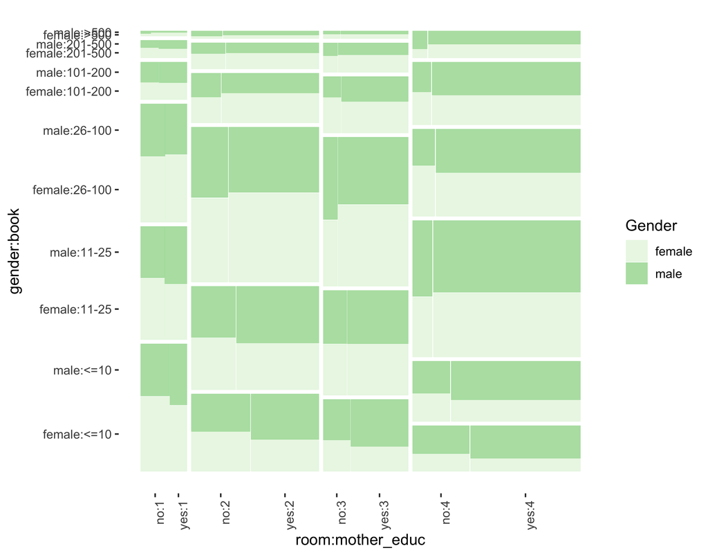

```r
ggplot(tur_book) +
  geom_mosaic(aes(x = product(gender, room, book,
         mother_educ),
    fill = gender),
    ) +
   scale_fill_discrete("Gender", palette = "Greens") +
  theme_mosaic() +
  theme(axis.text.x = element_text(angle = 90, hjust = 1))
```

## Double decker plots

- Explain
- Plot
- Data
- A double decker plot is a mosaic plot where one variable is treated as the response, plotted last.
- Explanatory (predictor) categorical variables are combined and shown side by side, with widths proportional to their combined counts.
- Within each combination of explanatory variables, a single bar is split (and coloured) by the response, showing the conditional probability of each response category.

Use when: you have a couple of categorical predictors and one categorical response, and want to compare how the response’s conditional distribution changes across combinations of predictors.

Compared to a mosaic plot, a double decker plot makes it easier to focus on one response variable at a time, at the cost of not showing area for the response split as clearly.

- 3
- 3 reorder
- 4
- 4 reorder

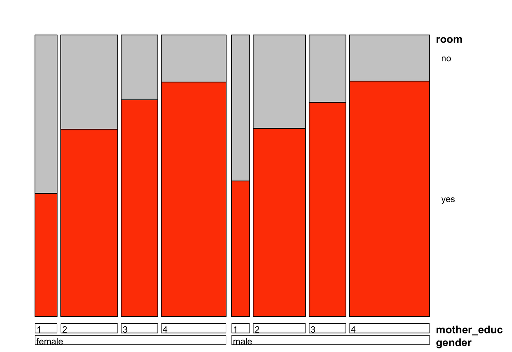

```r
tur_book2 <- student_tur |>
  filter(!is.na(book),
         !is.na(mother_educ),
         !is.na(gender)) |>
  mutate(
    book = factor(
      case_when(
        book %in% c("0-10", "11-25") ~ "<=25",
        book == "26-100" ~ "26-100",
        book == "101-200" ~ "101-200",
        TRUE ~ ">200"
      ),
      levels = c("<=25", "26-100", "101-200", ">200")
    ),
    mother_educ = factor(mother_educ,
      levels = c("less than ISCED1", "ISCED 1", "ISCED 2", "ISCED 3A"),
      labels = c("1", "2", "3", "4")
    )
  )

tur_dd_tbl <- xtabs(~ gender + mother_educ + room, data = tur_book2)
vcd::doubledecker(tur_dd_tbl,
  gp = grid::gpar(fill = c("grey80", "orangered")),
  labeling_args = list(gp_labels = grid::gpar(fontsize = 10)),
  margins = c(3, 7, 3, 3)
)
```

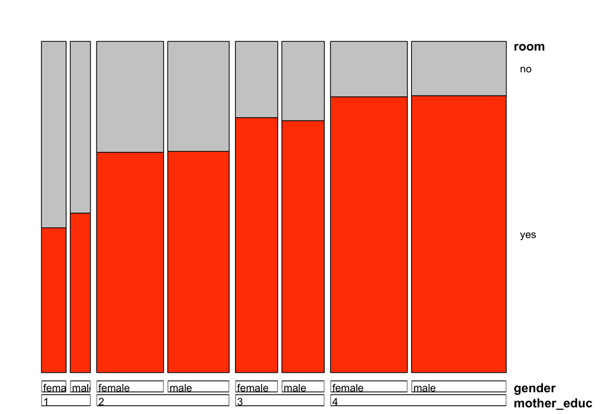

```r
tur_dd_tbl3 <- xtabs(~ mother_educ + gender + room, data = tur_book2)
vcd::doubledecker(tur_dd_tbl3,
  gp = grid::gpar(fill = c("grey80", "orangered")),
  labeling_args = list(gp_labels = grid::gpar(fontsize = 10)),
  margins = c(3, 7, 3, 3)
)
```

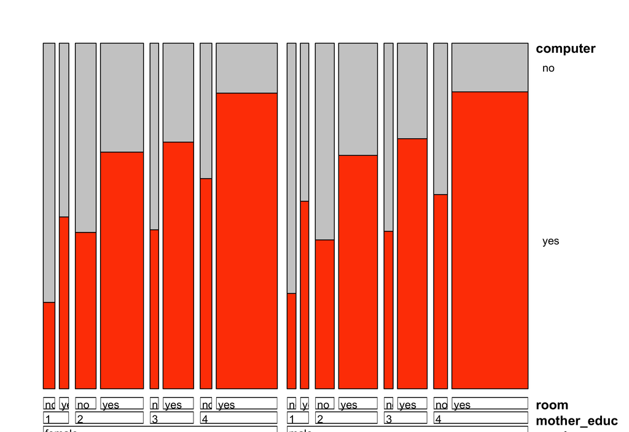

```r
tur_dd_tbl2 <- xtabs(~ gender + mother_educ + room + computer, data = tur_book2)
vcd::doubledecker(tur_dd_tbl2,
  gp = grid::gpar(fill = c("grey80", "orangered")),
  labeling_args = list(gp_labels = grid::gpar(fontsize = 10)),
  margins = c(3, 7, 3, 3)
)
```

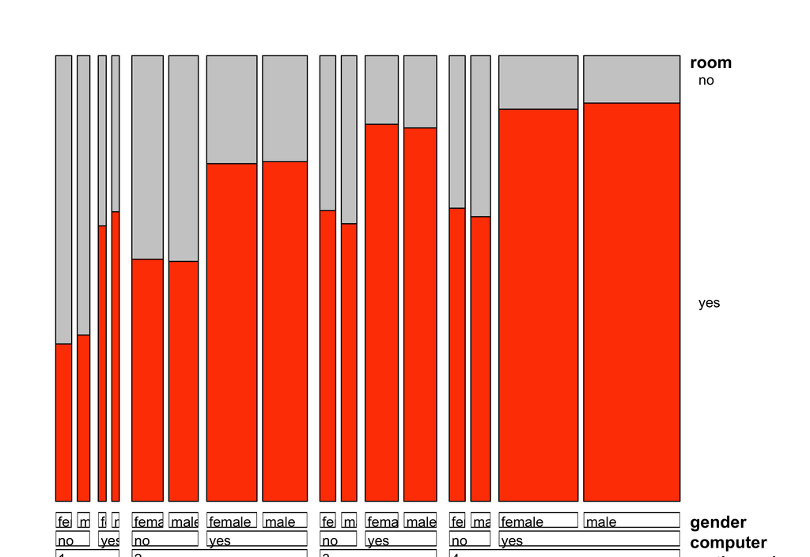

```r
tur_dd_tbl4 <- xtabs(~ mother_educ + computer + gender + room, data = tur_book2)
vcd::doubledecker(tur_dd_tbl4,
  gp = grid::gpar(fill = c("grey80", "orangered")),
  labeling_args = list(gp_labels = grid::gpar(fontsize = 10)),
  margins = c(3, 7, 3, 3)
)
```

## Paradoxes

## Simpsons paradox

There is an additional variable, which if used for conditioning, changes the association between the variables, you have a paradox.

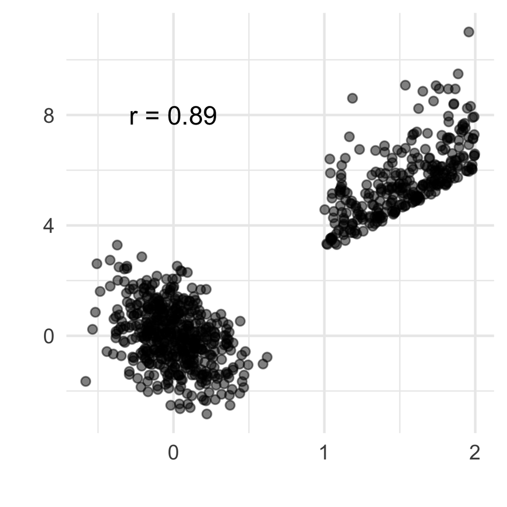

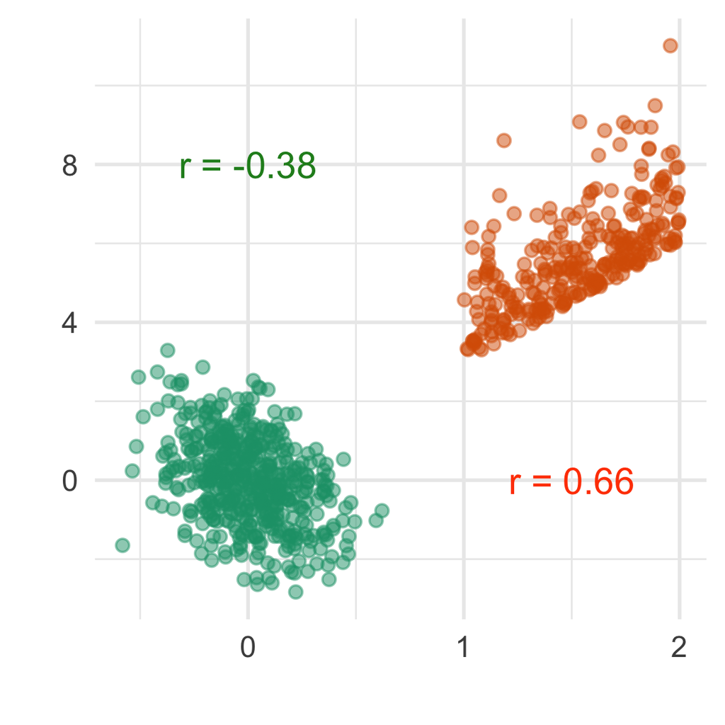